# Exercícios

Siga as instruções para recriar os gráficos usando estes dados:

## Dados

```python
import numpy as np
x = np.arange(0,100)
y = x*2
z = x**2
```

**Importe matplotlib.pyplot como plt e defina% matplotlib inline se você estiver usando o bloco de anotações jupyter. Que comando você usa se não estiver usando o notebook jupyter**

```python
import matplotlib.pyplot as plt
%matplotlib inline
```

## Exercício 1

**Siga estas etapas:**

- **Crie um objeto de figura chamado fig usando plt.figure ()**
- **Use add_axes para adicionar um eixo à tela da figura em [0,0,1,1]. Chame esse novo eixo de eixo.**
- **Plote (x, y) nesses eixos e defina os rótulos e títulos para coincidir com o gráfico abaixo:**

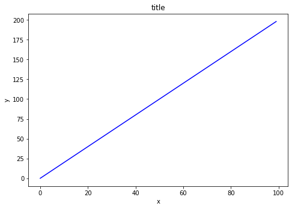

```python
fig = plt.figure()
eixo = fig.add_axes([0, 0, 1, 1])
eixo.plot(x, y, 'b')
eixo.set_xlabel('x')
eixo.set_ylabel('y')
eixo.set_title('title')
```

## Exercício 2

**Crie um objeto de figura e coloque dois eixos nele, ax1 e ax2. Localizado em [0,0,1,1] e [0,2,0,5, .2, .2], respectivamente.**

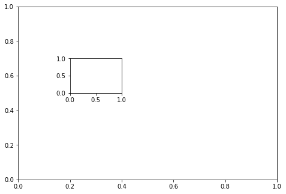

```python
fig = plt.figure()

ax1 = fig.add_axes([0,0,1,1])
ax2 = fig.add_axes([0.2,0.5,.2,.2])
```

**Agora plote (x, y) nos dois eixos. E chame seu objeto de figura para mostrá-lo.**

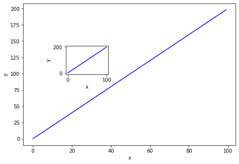

```python
ax1.plot(x, y, 'b')
ax1.set_xlabel('x')
ax1.set_ylabel('y')


ax2.plot(x, y, 'b')
ax2.set_xlabel('x')
ax2.set_ylabel('y')

fig
```

## Exercício 3

**Crie o gráfico abaixo adicionando dois eixos a um objeto de figura em [0,0,1,1] e [0,2,0,5, .4, .4]**

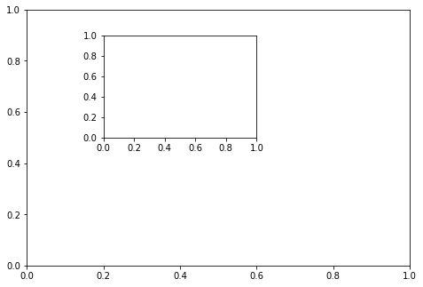

```python
fig = plt.figure()
ax1 = fig.add_axes([0, 0, 1, 1])
ax2 = fig.add_axes([0.2, 0.5, .4, .4])
```

**Agora use as matrizes x, ye z para recriar o gráfico abaixo. Observe os limites xlimits e y no gráfico inserido:**

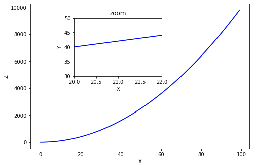

```python
ax1.plot(x,z,'b')
ax1.set_xlabel('X')
ax1.set_ylabel('Z')


ax2.plot(x,y,'b')
ax2.set_xlabel('X')
ax2.set_ylabel('Y')
ax2.set_title('zoom')
ax2.set_xlim(20,22)
ax2.set_ylim(30,50)

fig
```

## Exercício 4

**Use plt.subplots (nrows = 1, ncols = 2) para criar o gráfico abaixo.**

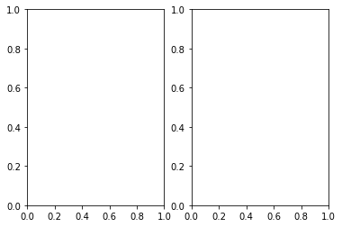

```python
fig, axes = plt.subplots(nrows=1, ncols=2)
```

**Agora plote (x, y) e (x, z) nos eixos. Brinque com a largura de linha e o estilo**

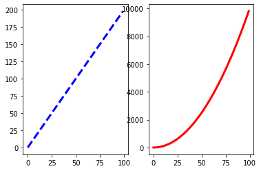

```python
axes[0].plot(x,y,color="blue", lw=3, ls='--')
axes[1].plot(x,z,color="red", lw=3, ls='-')
fig
```

**Veja se você pode redimensionar o gráfico adicionando o argumento figsize () em plt.subplots () está copiando e colando o código anterior.**

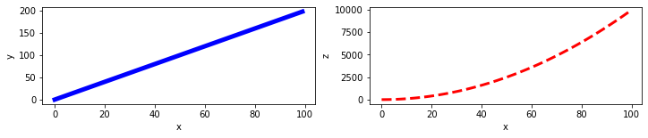

```python
fig, axes = plt.subplots(nrows=1, ncols=2,figsize=(12,2))

axes[0].plot(x,y,color="blue", lw=5)
axes[0].set_xlabel('x')
axes[0].set_ylabel('y')

axes[1].plot(x,z,color="red", lw=3, ls='--')
axes[1].set_xlabel('x')
axes[1].set_ylabel('z')
```